# Calculate Potential Evapotranspiration Using Thornthwaite Model

Hao-Ran Wu ( haoranwu @ zju.edu.cn )

2022-09-20

In this section we are concerned about how to calculate potential evapotranspiration (PET) using Thornthwaite model.

```r
# Calculate PET Using Thornthwaite Model
# ********************************
#
# Calculate PET based on Thornthwaite Model (Thornthwaite, 1948).
#
# ********************************
# List of variables and units for this example
#
# 't_a'      monthly mean air temperature (Celsius)
# 'Ld'       monthly mean day length (h)
# 'PET'      monthly potential evapotranspiration (cm)
#
# ********************************
# Step 1: import package
require(bproce)

# Step 2: read data
dat   <- read.csv("./data/4-1B Simulated Monthly Micrometeorological Varibles.csv")
              # load monthly micrometeorological data set
              #     Column 1 ($Month):   month of the year
              #     Column 2 ($Ta):      monthly mean air temperature (Celsius)
              #     Column 3 ($Ld):      monthly mean day length (h)

t_a  <- dat$Ta         # monthly mean air temperature
Ld   <- dat$Ld/12      # monthly mean daytime length

# Step 3: run the model
PET <- m2.PET.Thornthwaite(t_a, Ld)

# Step 4: present and visualize results
print(head(data.frame(
  t_a, Ld, PET
)), digits = 3)     # summarize the result

plot(
  1:12, PET, type = "l",
  xlab = "Month of the year",
  ylab = "Monthly PET",
  main = "PET Estimated by Thornthwaite Model"
)                   # plot PET versus time
```

## Explanation

**Step1:** Load the package `bproce` through the `require()` function.

```r
require(bproce)
```

**Step2:** Read data. Import the sample file through the function `read.csv`:

```r
dat   <- read.csv("./data/4-1B Simulated Monthly Micrometeorological Varibles.csv")
              # load monthly micrometeorological data set
              #     Column 1 ($Month):   month of the year
              #     Column 2 ($Ta):      monthly mean air temperature (Celsius)
              #     Column 3 ($Ld):      monthly mean day length (h)

head(dat)
```

```
  Month    Ta       Ld
1     1  1.05  9.48072
2     2  4.53 10.59146
3     3  9.31 11.99391
4     4 12.01 13.43173
5     5 19.99 14.64700
6     6 25.17 15.24827
```

Extract micrometeorological variables that are required in Thornthwaite Model from variable `dat`.

```r
t_a  <- dat$Ta         # monthly mean air temperature
Ld   <- dat$Ld/12      # monthly mean daytime length
```

**Step3:** Run the model. The Thornthwaite (1948) PET model is expressed as:

$$\text{PET}=1.6·L_d·\left( \frac{10·T}{I}\right)^a,\quad(1)$$

where:

- $\text{PET}$ = monthly PET (cm)
- $L_d$ = monthly mean daytime length in multiples of 12h
- $a = 6.75 × 10{-7}·I^3−7.71×10^{−5}·I^2+0.01792·I+0.49239$
- $I$ = annual heat index, which is computed from the monthly heat indices

$$I = \sum_{j=1}^{12}i_j,\quad(2)$$

where $i_j=\left(\frac{T_j}5\right)^{1.514}$ , $T_j$ is the mean air temperature (<sup>o</sup>C) per month.

```r
PET <- m2.PET.Thornthwaite(t_a, Ld)

print(head(data.frame(
  t_a, Ld, PET
)), digits = 3)     # summarize the result
```

```
    t_a    Ld     PET
1  1.05 0.790  0.0479
2  4.53 0.883  0.6179
3  9.31 0.999  2.3365
4 12.01 1.119  4.0073
5 19.99 1.221 10.2526
6 25.17 1.271 15.6967
```

**Step4:** Visualize results. Create a line plot of predicted PET against time through the function `plot()`:

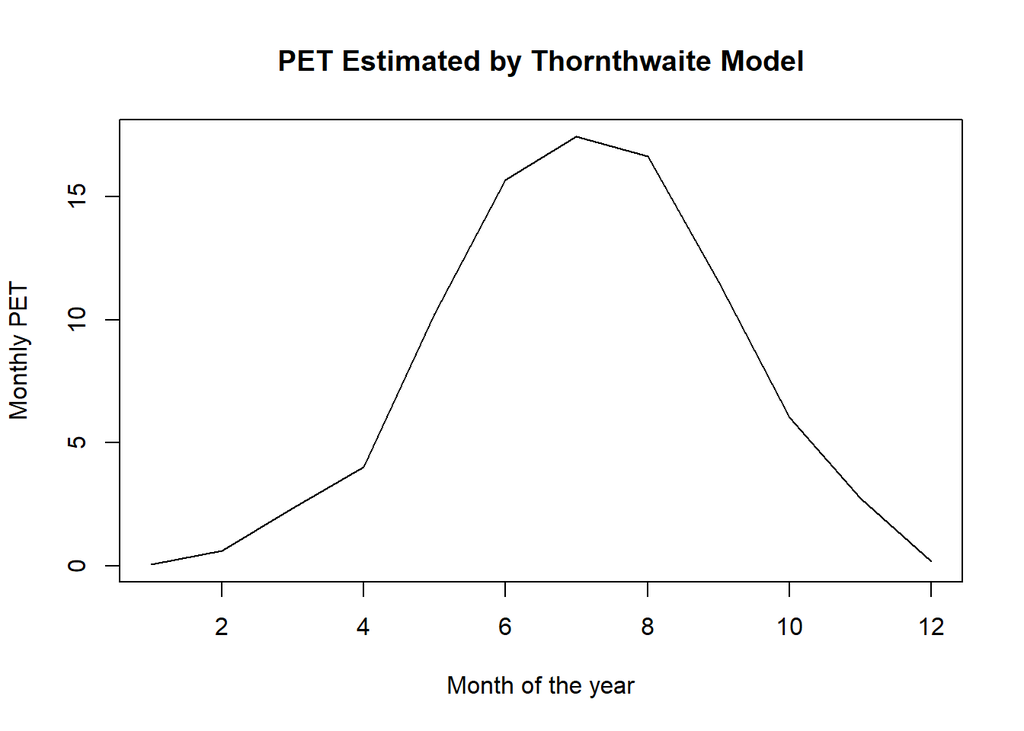

```r
plot(
  1:12, PET, type = "l",
  xlab = "Month of the year",
  ylab = "Monthly PET",
  main = "PET Estimated by Thornthwaite Model"
)                   # plot PET versus time
```

## References

Thornthwaite, C. W. (1948). An approach toward a Rational classification of climate. Geographical Review, 38(1), 55–94.

Zenone, T., Chen, J., Deal, M. W., Wilske, B., Jasrotia, P., Xu, J., Bhardwaj, A. K., Hamilton, S. K., and Robertson, G. P. (2011). CO<sub>2</sub> fluxes of transitional bioenergy crops: Effect of land conversion during the first year of cultivation. Global Change Biology-Bioenergy, 3(5), 401–412.